# 2020-08-09-MarkovChain

2020-08-09

## Entendiendo las simulaciones de Markov

Un tema o una rama de la estadística que ha cobrado un nuevo nivel de importancia dada su aplicación en temas como: las finanzas, logística, marketing y forecasting son las cadenas de Markov. Estas mismas pertenecen a lo que se conoce como procesos estocásticos, lo cual quiere decir que son magnitudes de procesos aleatorios que varia con el tiempo, y puntualmente en el caso de la simulación de monte carlo con Markov se aplica la siguiente regla:

$$P(X_{n}=i_n|X_{n-1}=i_{n-1})=P(X_{n}=i_n|X_{0}=i_{0},X_{1}=i_{1},...,X_{n}=i_{n})$$

Esta regla se le conoce como propiedad de Markov, en donde cada evento solo responde únicamente a $X_{n-1}$ y $P(X_{n}|X_{n-1})$ es una matriz de transacción, la cual contiene información sobre las probabilidades de los diferentes estados de los datos dada las condiciones antes mencionadas.

Una característica del producto de las matrices es que pueden describir las probabilidades de las transacciones a lo largo de un período de tiempo definido. Por lo tanto los estados transitorios deben alcanzar la probabilidad 1 gracias al estado inicial de la función de distribución.

Por lo tanto una propiedad fundamental de que la matriz sea estacionaria y tenga la regla de Markov es que la distribución limite del estado $X_{n-1}$ sea $X_{n-1} \sim f$ entonces $X_{n} \sim f$,lo que asegura la recurrencia, bajo la condición de $X_{n+1}=X_t + e_t$ donde $e_t$ sigue una distribución normal y la forma de la densidad se convierte en una normal. Esto quiere decir que la cadena tiene una propiedad de caminata aleatoria

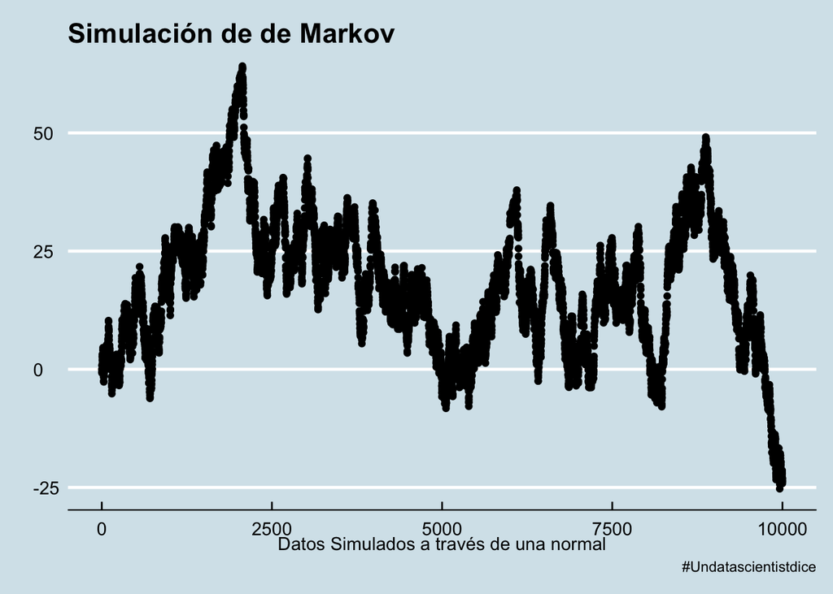